# Random Forest

##### Step 1: Load the Libraries

```python
import warnings
warnings.filterwarnings('ignore')
```

```python
from IPython.core.interactiveshell import InteractiveShell
InteractiveShell.ast_node_interactivity = 'all'
```

```python
import numpy as np
import pandas as pd
import matplotlib.pyplot as plt
import seaborn as sns
import time

%matplotlib inline

plt.style.use('fast')
sns.set_style('whitegrid')
```

##### Step 2: Load the data

# Data Info

**Problem Statement**: The data is from direct marketing campaigns (phone calls) of a banking institution. The classification goal is to predict if the client will subscribe a term deposit.

Attribute Information:

Input variables:

### Bank client data:

1 – age (numeric)

2 – job : type of job (categorical: ‘admin.’,’blue-collar’,’entrepreneur’,’housemaid’,’management’,’retired’,’self-employed’,’services’,’student’,’technician’,’unemployed’,’unknown’)

3 – marital : marital status (categorical: ‘divorced’,’married’,’single’,’unknown’; note: ‘divorced’ means divorced or widowed)

4 – education (categorical: ‘basic.4y’,’basic.6y’,’basic.9y’,’high.school’,’illiterate’,’professional.course’,’university.degree’,’unknown’)

5 – default: has credit in default? (categorical: ‘no’,’yes’,’unknown’)

6 – housing: has housing loan? (categorical: ‘no’,’yes’,’unknown’)

7 – loan: has personal loan? (categorical: ‘no’,’yes’,’unknown’)

### related with the last contact of the current campaign:

8 – contact: contact communication type (categorical: ‘cellular’,’telephone’)

9 – month: last contact month of year (categorical: ‘jan’, ‘feb’, ‘mar’, …, ‘nov’, ‘dec’)

10 – day_of_week: last contact day of the week (categorical: ‘mon’,’tue’,’wed’,’thu’,’fri’)

11 – duration: last contact duration, in seconds (numeric). Important note: this attribute highly affects the output target (e.g., if duration=0 then y=’no’). Yet, the duration is not known before a call is performed. Also, after the end of the call y is obviously known. Thus, this input should only be included for benchmark purposes and should be discarded if the intention is to have a realistic predictive model.

### other attributes:

12 – campaign: number of contacts performed during this campaign and for this client (numeric, includes last contact)

13 – pdays: number of days that passed by after the client was last contacted from a previous campaign (numeric; 999 means client was not previously contacted)

14 – previous: number of contacts performed before this campaign and for this client (numeric)

15 – poutcome: outcome of the previous marketing campaign (categorical: ‘failure’,’nonexistent’,’success’)

### social and economic context attributes

16 – emp.var.rate: employment variation rate – quarterly indicator (numeric)

17 – cons.price.idx: consumer price index – monthly indicator (numeric)

18 – cons.conf.idx: consumer confidence index – monthly indicator (numeric)

19 – euribor3m: euribor 3 month rate – daily indicator (numeric) - The Euro Interbank Offered Rate (Euribor) is a daily reference rate, published by the European Money Markets Institute, based on the averaged interest rates .

20 – nr.employed: number of employees – quarterly indicator (numeric)

### Output variable (desired target):

21 – y – has the client subscribed a term deposit? (binary: ‘yes’,’no’)

```python
# Load the data

bankdf = pd.read_csv(r'C:\Users\..\bank-data.csv')
```

```python
bankdf.head()
```

|  | age;"job";"marital";"education";"default";"housing";"loan";"contact";"month";"day_of_week";"duration";"campaign";"pdays";"previous";"poutcome";"emp.var.rate";"cons.price.idx";"cons.conf.idx";"euribor3… |
| --- | --- |
| 0 | 56;"housemaid";"married";"basic.4y";"no";"no";... |
| 1 | 57;"services";"married";"high.school";"unknown... |
| 2 | 37;"services";"married";"high.school";"no";"ye... |
| 3 | 40;"admin.";"married";"basic.6y";"no";"no";"no... |
| 4 | 56;"services";"married";"high.school";"no";"no... |

```python
bankdf = pd.read_csv(r'C:\Users\amaresh.murthiraju\Documents\Course Material\ML\07 Random Forest\bank-data.csv'
                     , sep = ';')
```

```python
bankdf.head()
```

|  | age | job | marital | education | default | housing | loan | contact | month | day_of_week | ... | campaign | pdays | previous | poutcome | emp.var.rate | cons.price.idx | cons.conf.idx | euribor3m | nr.employed | y |
| --- | --- | --- | --- | --- | --- | --- | --- | --- | --- | --- | --- | --- | --- | --- | --- | --- | --- | --- | --- | --- | --- |
| 0 | 56 | housemaid | married | basic.4y | no | no | no | telephone | may | mon | ... | 1 | 999 | 0 | nonexistent | 1.1 | 93.994 | -36.4 | 4.857 | 5191.0 | no |
| 1 | 57 | services | married | high.school | unknown | no | no | telephone | may | mon | ... | 1 | 999 | 0 | nonexistent | 1.1 | 93.994 | -36.4 | 4.857 | 5191.0 | no |
| 2 | 37 | services | married | high.school | no | yes | no | telephone | may | mon | ... | 1 | 999 | 0 | nonexistent | 1.1 | 93.994 | -36.4 | 4.857 | 5191.0 | no |
| 3 | 40 | admin. | married | basic.6y | no | no | no | telephone | may | mon | ... | 1 | 999 | 0 | nonexistent | 1.1 | 93.994 | -36.4 | 4.857 | 5191.0 | no |
| 4 | 56 | services | married | high.school | no | no | yes | telephone | may | mon | ... | 1 | 999 | 0 | nonexistent | 1.1 | 93.994 | -36.4 | 4.857 | 5191.0 | no |

5 rows × 21 columns

```python
bankdf.info()
```

```
<class 'pandas.core.frame.DataFrame'>
RangeIndex: 41188 entries, 0 to 41187
Data columns (total 21 columns):
age               41188 non-null int64
job               41188 non-null object
marital           41188 non-null object
education         41188 non-null object
default           41188 non-null object
housing           41188 non-null object
loan              41188 non-null object
contact           41188 non-null object
month             41188 non-null object
day_of_week       41188 non-null object
duration          41188 non-null int64
campaign          41188 non-null int64
pdays             41188 non-null int64
previous          41188 non-null int64
poutcome          41188 non-null object
emp.var.rate      41188 non-null float64
cons.price.idx    41188 non-null float64
cons.conf.idx     41188 non-null float64
euribor3m         41188 non-null float64
nr.employed       41188 non-null float64
y                 41188 non-null object
dtypes: float64(5), int64(5), object(11)
memory usage: 6.6+ MB
```

```python
bankdf.shape
```

```
(41188, 21)
```

```python
bankdf.describe()
```

|  | age | duration | campaign | pdays | previous | emp.var.rate | cons.price.idx | cons.conf.idx | euribor3m | nr.employed |
| --- | --- | --- | --- | --- | --- | --- | --- | --- | --- | --- |
| count | 41188.00000 | 41188.000000 | 41188.000000 | 41188.000000 | 41188.000000 | 41188.000000 | 41188.000000 | 41188.000000 | 41188.000000 | 41188.000000 |
| mean | 40.02406 | 258.285010 | 2.567593 | 962.475454 | 0.172963 | 0.081886 | 93.575664 | -40.502600 | 3.621291 | 5167.035911 |
| std | 10.42125 | 259.279249 | 2.770014 | 186.910907 | 0.494901 | 1.570960 | 0.578840 | 4.628198 | 1.734447 | 72.251528 |
| min | 17.00000 | 0.000000 | 1.000000 | 0.000000 | 0.000000 | -3.400000 | 92.201000 | -50.800000 | 0.634000 | 4963.600000 |
| 25% | 32.00000 | 102.000000 | 1.000000 | 999.000000 | 0.000000 | -1.800000 | 93.075000 | -42.700000 | 1.344000 | 5099.100000 |
| 50% | 38.00000 | 180.000000 | 2.000000 | 999.000000 | 0.000000 | 1.100000 | 93.749000 | -41.800000 | 4.857000 | 5191.000000 |
| 75% | 47.00000 | 319.000000 | 3.000000 | 999.000000 | 0.000000 | 1.400000 | 93.994000 | -36.400000 | 4.961000 | 5228.100000 |
| max | 98.00000 | 4918.000000 | 56.000000 | 999.000000 | 7.000000 | 1.400000 | 94.767000 | -26.900000 | 5.045000 | 5228.100000 |

```python
bankdf.isnull().sum()
```

```
age               0
job               0
marital           0
education         0
default           0
housing           0
loan              0
contact           0
month             0
day_of_week       0
duration          0
campaign          0
pdays             0
previous          0
poutcome          0
emp.var.rate      0
cons.price.idx    0
cons.conf.idx     0
euribor3m         0
nr.employed       0
y                 0
dtype: int64
```

Exploratory Data Analysis -> Loading upto Model building.

##### Get the list of numerical columns

```python
num_cols = list(bankdf.select_dtypes(include=np.number))
print(num_cols)
```

```
['age', 'duration', 'campaign', 'pdays', 'previous', 'emp.var.rate', 'cons.price.idx', 'cons.conf.idx', 'euribor3m', 'nr.employed']
```

##### Get the list of Categorical columns

```python
cat_cols = list(bankdf.select_dtypes(include='object'))
print(cat_cols)
```

```
['job', 'marital', 'education', 'default', 'housing', 'loan', 'contact', 'month', 'day_of_week', 'poutcome', 'y']
```

##### Check the unique values of Categorical columns

```python
for i in cat_cols:
    print(i, '---->', bankdf[i].unique())
    print('\n','-'*75)
```

```
job ----> ['housemaid' 'services' 'admin.' 'blue-collar' 'technician' 'retired'
 'management' 'unemployed' 'self-employed' 'unknown' 'entrepreneur'
 'student']

 ---------------------------------------------------------------------------
marital ----> ['married' 'single' 'divorced' 'unknown']

 ---------------------------------------------------------------------------
education ----> ['basic.4y' 'high.school' 'basic.6y' 'basic.9y' 'professional.course'
 'unknown' 'university.degree' 'illiterate']

 ---------------------------------------------------------------------------
default ----> ['no' 'unknown' 'yes']

 ---------------------------------------------------------------------------
housing ----> ['no' 'yes' 'unknown']

 ---------------------------------------------------------------------------
loan ----> ['no' 'yes' 'unknown']

 ---------------------------------------------------------------------------
contact ----> ['telephone' 'cellular']

 ---------------------------------------------------------------------------
month ----> ['may' 'jun' 'jul' 'aug' 'oct' 'nov' 'dec' 'mar' 'apr' 'sep']

 ---------------------------------------------------------------------------
day_of_week ----> ['mon' 'tue' 'wed' 'thu' 'fri']

 ---------------------------------------------------------------------------
poutcome ----> ['nonexistent' 'failure' 'success']

 ---------------------------------------------------------------------------
y ----> ['no' 'yes']

 ---------------------------------------------------------------------------
```

```python
(bankdf == 'unknown').sum()
```

```
age                  0
job                330
marital             80
education         1731
default           8597
housing            990
loan               990
contact              0
month                0
day_of_week          0
duration             0
campaign             0
pdays                0
previous             0
poutcome             0
emp.var.rate         0
cons.price.idx       0
cons.conf.idx        0
euribor3m            0
nr.employed          0
y                    0
dtype: int64
```

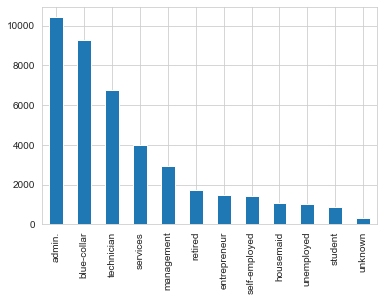

```python
bankdf.job.value_counts().plot(kind='bar');
```

```python
type((bankdf == 'unknown').sum())
```

```
pandas.core.series.Series
```

```python
df = pd.DataFrame((bankdf == 'unknown').sum()).reset_index()
```

```python
df.columns = ['var', 'count']
```

```python
df.head(10)
```

|  | var | count |
| --- | --- | --- |
| 0 | age | 0 |
| 1 | job | 330 |
| 2 | marital | 80 |
| 3 | education | 1731 |
| 4 | default | 8597 |
| 5 | housing | 990 |
| 6 | loan | 990 |
| 7 | contact | 0 |
| 8 | month | 0 |
| 9 | day_of_week | 0 |

```python
unkwn_cols = df[df['count'] > 0]['var'].tolist()
print(unkwn_cols)
```

```
['job', 'marital', 'education', 'default', 'housing', 'loan']
```

```python
np.sort(bankdf['job'].unique())
```

```
array(['admin.', 'blue-collar', 'entrepreneur', 'housemaid', 'management',
       'retired', 'self-employed', 'services', 'student', 'technician',
       'unemployed', 'unknown'], dtype=object)
```

```python
bankdf['job'].value_counts()
```

```
admin.           10422
blue-collar       9254
technician        6743
services          3969
management        2924
retired           1720
entrepreneur      1456
self-employed     1421
housemaid         1060
unemployed        1014
student            875
unknown            330
Name: job, dtype: int64
```

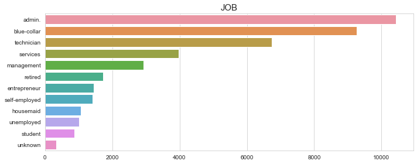

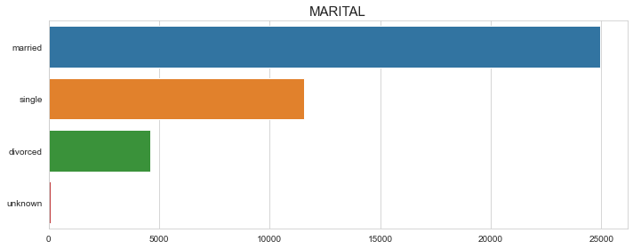

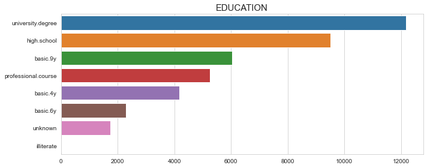

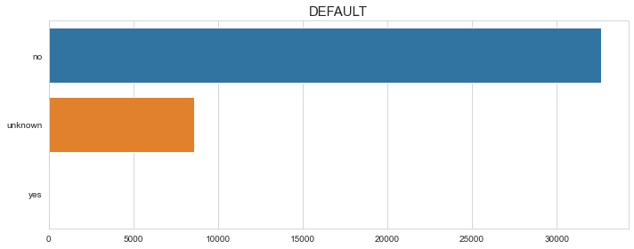

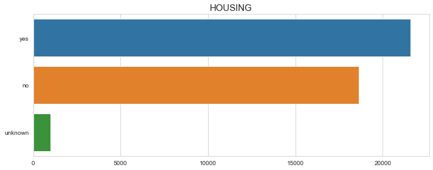

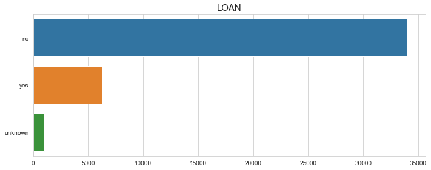

```python
for i in unkwn_cols:
    plt.figure(figsize=(10,4))
    sns.barplot(y = bankdf[i].value_counts().index , x = bankdf[i].value_counts().values)
    plt.title(str(i).upper(), size = 15)
    plt.tight_layout()
plt.show();
```

```python
bankdf.columns[np.where(bankdf.dtypes == 'object')]
```

```
Index(['job', 'marital', 'education', 'default', 'housing', 'loan', 'contact',
       'month', 'day_of_week', 'poutcome', 'y'],
      dtype='object')
```

```python
from sklearn.preprocessing import LabelEncoder
```

```python
categorical_cols = bankdf.columns[np.where(bankdf.dtypes == 'object')]
```

```python
categorical_cols
```

```
Index(['job', 'marital', 'education', 'default', 'housing', 'loan', 'contact',
       'month', 'day_of_week', 'poutcome', 'y'],
      dtype='object')
```

```python
le = LabelEncoder()
```

```python
for i in categorical_cols:
    bankdf[i] = le.fit_transform(bankdf[i])
```

```python
bankdf.dtypes
```

```
age                 int64
job                 int32
marital             int32
education           int32
default             int32
housing             int32
loan                int32
contact             int32
month               int32
day_of_week         int32
duration            int64
campaign            int64
pdays               int64
previous            int64
poutcome            int32
emp.var.rate      float64
cons.price.idx    float64
cons.conf.idx     float64
euribor3m         float64
nr.employed       float64
y                   int32
dtype: object
```

#### Model Building

```python
bankdf.head()
```

|  | age | job | marital | education | default | housing | loan | contact | month | day_of_week | ... | campaign | pdays | previous | poutcome | emp.var.rate | cons.price.idx | cons.conf.idx | euribor3m | nr.employed | y |
| --- | --- | --- | --- | --- | --- | --- | --- | --- | --- | --- | --- | --- | --- | --- | --- | --- | --- | --- | --- | --- | --- |
| 0 | 56 | 3 | 1 | 0 | 0 | 0 | 0 | 1 | 6 | 1 | ... | 1 | 999 | 0 | 1 | 1.1 | 93.994 | -36.4 | 4.857 | 5191.0 | 0 |
| 1 | 57 | 7 | 1 | 3 | 1 | 0 | 0 | 1 | 6 | 1 | ... | 1 | 999 | 0 | 1 | 1.1 | 93.994 | -36.4 | 4.857 | 5191.0 | 0 |
| 2 | 37 | 7 | 1 | 3 | 0 | 2 | 0 | 1 | 6 | 1 | ... | 1 | 999 | 0 | 1 | 1.1 | 93.994 | -36.4 | 4.857 | 5191.0 | 0 |
| 3 | 40 | 0 | 1 | 1 | 0 | 0 | 0 | 1 | 6 | 1 | ... | 1 | 999 | 0 | 1 | 1.1 | 93.994 | -36.4 | 4.857 | 5191.0 | 0 |
| 4 | 56 | 7 | 1 | 3 | 0 | 0 | 2 | 1 | 6 | 1 | ... | 1 | 999 | 0 | 1 | 1.1 | 93.994 | -36.4 | 4.857 | 5191.0 | 0 |

5 rows × 21 columns

```python
# Separate IV and DV

X = bankdf.drop(['y','duration'], axis = 1)
Y = bankdf.y
```

```python
from sklearn.model_selection import train_test_split
X_train, X_test, y_train, y_test = train_test_split(X,Y, test_size = 0.25, random_state = 101)
```

```python
# Random Forest classifier

from sklearn.ensemble import RandomForestClassifier

rfc1 = RandomForestClassifier()
```

```python
rfc1.fit(X_train, y_train)
```

```
RandomForestClassifier(bootstrap=True, class_weight=None, criterion='gini',
                       max_depth=None, max_features='auto', max_leaf_nodes=None,
                       min_impurity_decrease=0.0, min_impurity_split=None,
                       min_samples_leaf=1, min_samples_split=2,
                       min_weight_fraction_leaf=0.0, n_estimators=10,
                       n_jobs=None, oob_score=False, random_state=None,
                       verbose=0, warm_start=False)
```

```python
y_train_pred1 = rfc1.predict(X_train)

y_test_pred1 = rfc1.predict(X_test)
```

```python
from sklearn.metrics import accuracy_score
```

```python
accuracy_score(y_train,y_train_pred1)

accuracy_score(y_test, y_test_pred1)
```

```
0.982713411673303
```

```
0.8893852578420899
```

```python
# model used all IVs

X_train.columns
```

```
Index(['age', 'job', 'marital', 'education', 'default', 'housing', 'loan',
       'contact', 'month', 'day_of_week', 'campaign', 'pdays', 'previous',
       'poutcome', 'emp.var.rate', 'cons.price.idx', 'cons.conf.idx',
       'euribor3m', 'nr.employed'],
      dtype='object')
```

### Feature importance

```python
rfc1.feature_importances_
```

```
array([0.18210228, 0.09046989, 0.04173136, 0.07608844, 0.01482803,
       0.03637131, 0.0263864 , 0.01625636, 0.01626721, 0.06082998,
       0.08097983, 0.04804747, 0.0140111 , 0.04535913, 0.02153121,
       0.0184451 , 0.03939952, 0.13879572, 0.03209965])
```

```python
f_imp = rfc1.feature_importances_
```

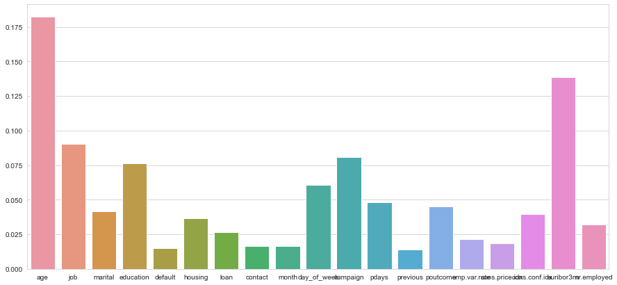

```python
plt.figure(figsize=(15,7))
sns.barplot(x = X_train.columns, y = rfc1.feature_importances_)
plt.show();
```

```python
np.argsort(rfc1.feature_importances_)
```

```
array([12,  4,  7,  8, 15, 14,  6, 18,  5, 16,  2, 13, 11,  9,  3, 10,  1,
       17,  0], dtype=int64)
```

```python
sorted_idx = np.argsort(rfc1.feature_importances_)
```

```python
X_train.columns[sorted_idx]
```

```
Index(['previous', 'default', 'contact', 'month', 'cons.price.idx',
       'emp.var.rate', 'loan', 'nr.employed', 'housing', 'cons.conf.idx',
       'marital', 'poutcome', 'pdays', 'day_of_week', 'education', 'campaign',
       'job', 'euribor3m', 'age'],
      dtype='object')
```

```python
f_imp[sorted_idx]
```

```
array([0.0140111 , 0.01482803, 0.01625636, 0.01626721, 0.0184451 ,
       0.02153121, 0.0263864 , 0.03209965, 0.03637131, 0.03939952,
       0.04173136, 0.04535913, 0.04804747, 0.06082998, 0.07608844,
       0.08097983, 0.09046989, 0.13879572, 0.18210228])
```

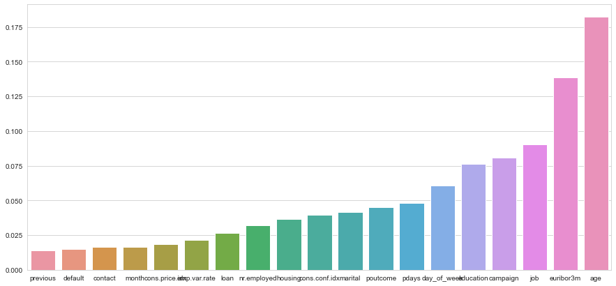

```python
plt.figure(figsize=(15,7))
sns.barplot(x = X_train.columns[sorted_idx], y = f_imp[sorted_idx])
plt.show();
```

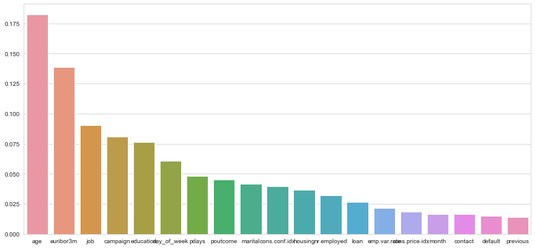

```python
plt.figure(figsize=(15,7))
sns.barplot(x = X_train.columns[sorted_idx][::-1], y = f_imp[sorted_idx][::-1])
plt.show();
```

### Check with RFE

```python
from sklearn.feature_selection import RFE
```

```python
X_train, X_test, y_train, y_test = train_test_split(X,Y, test_size = 0.25, random_state = 101)
```

```python
rfe1 = RFE(RandomForestClassifier(), 6)
```

```python
rfe1_fit = rfe1.fit(X_train,y_train)
```

```python
rfe1_fit.support_
```

```
array([ True,  True, False,  True, False, False, False, False, False,
       False,  True, False, False, False, False, False, False,  True,
        True])
```

```python
rfe1_fit.ranking_
```

```
array([ 1,  1,  5,  1, 13,  6,  8, 14, 10,  3,  1, 11,  9,  2, 12,  7,  4,
        1,  1])
```

```python
x = []
for i, j in enumerate(rfe1_fit.ranking_):
    if(j == 1):
        x.append(X_train.columns[i])
print(x)
```

```
['age', 'job', 'education', 'campaign', 'euribor3m', 'nr.employed']
```

```python
# selected imp features

imp_iv = ['age', 'job', 'education', 'campaign', 'euribor3m']
```

```python
# Separate IV and DV based on Feature selection output

X = bankdf[imp_iv]
y = bankdf.y
```

```python
from sklearn.model_selection import train_test_split
X_train, X_test, y_train, y_test = train_test_split(X,Y, test_size = 0.25, random_state = 101)
```

```python
# Random Forest classifier

from sklearn.ensemble import RandomForestClassifier

rfc1 = RandomForestClassifier()
```

```python
rfc1.fit(X_train, y_train)
```

```
RandomForestClassifier(bootstrap=True, class_weight=None, criterion='gini',
                       max_depth=None, max_features='auto', max_leaf_nodes=None,
                       min_impurity_decrease=0.0, min_impurity_split=None,
                       min_samples_leaf=1, min_samples_split=2,
                       min_weight_fraction_leaf=0.0, n_estimators=10,
                       n_jobs=None, oob_score=False, random_state=None,
                       verbose=0, warm_start=False)
```

```python
y_train_pred1 = rfc1.predict(X_train)

y_test_pred1 = rfc1.predict(X_test)
```

```python
from sklearn.metrics import accuracy_score
```

```python
accuracy_score(y_train,y_train_pred1)

accuracy_score(y_test, y_test_pred1)
```

```
0.9657505422291283
```

```
0.876274643099932
```

```python
print((0.8893852578420899 - 0.876274643099932)*100)
```

```
1.3110614742157911
```

### Hyper-Parameter tuning

```python
from sklearn.model_selection import GridSearchCV
```

```python
pram_grid = {'n_estimators' : [20,50,100],
            'criterion': ['gini', 'entropy'],
            'max_features':[1,2,3]}
```

```python
model = RandomForestClassifier()
```

```python
grid_results = GridSearchCV(model, pram_grid, cv = 5)
```

```python
start = time.time()

grid_results.fit(X_train.values, y_train.values)

end = time.time()

print(end-start)
```

```
GridSearchCV(cv=5, error_score='raise-deprecating',
             estimator=RandomForestClassifier(bootstrap=True, class_weight=None,
                                              criterion='gini', max_depth=None,
                                              max_features='auto',
                                              max_leaf_nodes=None,
                                              min_impurity_decrease=0.0,
                                              min_impurity_split=None,
                                              min_samples_leaf=1,
                                              min_samples_split=2,
                                              min_weight_fraction_leaf=0.0,
                                              n_estimators='warn', n_jobs=None,
                                              oob_score=False,
                                              random_state=None, verbose=0,
                                              warm_start=False),
             iid='warn', n_jobs=None,
             param_grid={'criterion': ['gini', 'entropy'],
                         'max_features': [1, 2, 3],
                         'n_estimators': [20, 50, 100]},
             pre_dispatch='2*n_jobs', refit=True, return_train_score=False,
             scoring=None, verbose=0)
```

```
141.95122981071472
```

```python
grid_results.best_score_
```

```
0.877213427859247
```

```python
grid_results.best_params_
```

```
{'criterion': 'gini', 'max_features': 2, 'n_estimators': 50}
```

```python
grid_results.best_estimator_
```

```
RandomForestClassifier(bootstrap=True, class_weight=None, criterion='gini',
                       max_depth=None, max_features=2, max_leaf_nodes=None,
                       min_impurity_decrease=0.0, min_impurity_split=None,
                       min_samples_leaf=1, min_samples_split=2,
                       min_weight_fraction_leaf=0.0, n_estimators=50,
                       n_jobs=None, oob_score=False, random_state=None,
                       verbose=0, warm_start=False)
```

## Visualizing on Tree/Estimator from RandomForest

```python
from sklearn.tree import export_graphviz
from subprocess import call
from IPython.display import Image
```

```python
best_model = grid_results.best_estimator_
```

```python
estimator = best_model.estimators_[1]
```

```python
# Export a tree from the forest
export_graphviz(estimator, 'tree_from_optimized_forest.dot', rounded = True,
                feature_names=X_train.columns, max_depth = 4,
                class_names = ['poverty', 'no poverty'], filled = True)
```

```
0
```

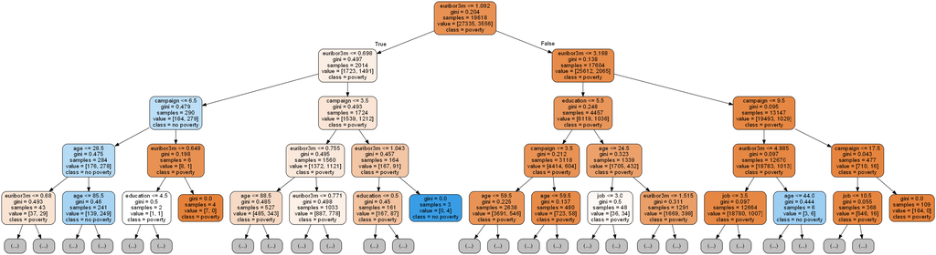

```python
call(['dot', '-Tpng', 'tree_from_optimized_forest.dot', '-o', 'tree_from_optimized_forest.png', '-Gdpi=100'])
Image('tree_from_optimized_forest.png')
```